# RAVED: Differential Expression Analysis for Gene Expression Microarry Data – GSE63142 severe_asthma vs healthy (adjusting by Scan Year (2012 vs 2011+2010)

Mengyuan Kan (mengykan@upenn.edu)

14 May, 2018

This report shows the differential analysis for gene expression microarry data from GEO study, including:

- Raw probe intensity normalization
- Differential expression
- Adjusting for batch effect

Input:

A pre-prepared phenotype file contains GEO_ID, Tissue, Disease and Treatment information.

Outputs:

- Gene differential expression result file(s) (.csv)
- A gene expression analysis report (.html)

Mannually change the variables for GEO ID (geo_id), data directory (datadir), result directory (resdir), tissue, disease/treatment status, and comparison conditions

**Note that** three variables, platform (platform), usesuppl (whether to use supplementary data for DE analysis), and normdata (whether the expression matrix is normalized), need to be **manually** defined based on the QC reports. A shortname_func function is suggested to be updated.

Install the prerequisite R packages if they do not exist

- GEOquery
- oligo
- limma
- sva
- annotate
- Bioconductor AnnotationData Packages: hgu133plus2.db, hgug4112a.db, hugene10sttranscriptcluster.db
- viridis (heatmap color)
- ggplot2
- gplots (heatmap2 plot)
- devtools (compute pca)
- pander

Load the necessary libraries

## Obtain Phenotype and GEO Data

### Phenotype data preparation

Read in pre-prepared phenotype data

```
## 'data.frame':    155 obs. of  11 variables:
##  $ GEO_ID        : Factor w/ 155 levels "GSM1541999","GSM1542000",..: 1 2 3 4 5 6 7 8 9 10 ...
##  $ Subject       : Factor w/ 72 levels "rep1","rep10",..: 1 12 23 34 45 56 67 71 72 2 ...
##  $ Sample        : Factor w/ 155 levels "GSM1541999_rep1",..: 1 2 3 4 5 6 7 8 9 10 ...
##  $ Tissue        : Factor w/ 1 level "BE": 1 1 1 1 1 1 1 1 1 1 ...
##  $ Organism      : Factor w/ 1 level "Human": 1 1 1 1 1 1 1 1 1 1 ...
##  $ Treatment     : Factor w/ 1 level "Baseline": 1 1 1 1 1 1 1 1 1 1 ...
##  $ Disease       : Factor w/ 3 levels "healthy","non_severe_asthma",..: 1 1 1 1 1 1 1 1 1 1 ...
##  $ ScanDate_Group: Factor w/ 14 levels "06-14-2011","06-15-2011",..: 8 13 5 9 6 10 4 5 8 5 ...
##  $ QC_Pass       : int  1 1 1 1 1 1 1 1 1 1 ...
##  $ Filename      : Factor w/ 155 levels "GSM1541999","GSM1542000",..: 1 2 3 4 5 6 7 8 9 10 ...
##  $ ScanYear      : Factor w/ 2 levels "2010-2011","2012": 1 2 1 1 1 1 1 1 1 1 ...
```

Subset phenotypes based on the comparison variables. Check variables (before and after QC if outliers are detected).

Summary of subsetted samples

| ScanYear | Status | Counts |
| --- | --- | --- |
| 2010-2011 | healthy | 20 |
| 2012 | healthy | 7 |
| 2010-2011 | severe_asthma | 44 |
| 2012 | severe_asthma | 12 |

Summary of the comparison

| **GEO_ID** | GSE63142 |
| --- | --- |
| **Tissue** | BE |
| **App** | Asthma |
| **Disease** | severe_asthma |
| **Treatment** | Baseline |
| **N_Condition0** | 27 |
| **N_Condition1** | 56 |
| **Total** | 83 |
| **Unique_ID** | GSE63142_BE_Baseline_severe_asthma_vs_healthy |

Assign colours to status and scan year (if available)

### Gene expression data preparation

For data from Affymetrix platform, raw probe intensity data from supplementary files (usually .cel files) in GEO are downloaded and used for DE analysis. For data from Agilent platform, the intensity data is derived from GEO expression matrix.

Generate raw.data object using supplementary files (for Affymetrix data).

Generate raw.data object using expression matrix from GEO (for platforms other than Affymetrix).

Obtain raw.data.of.interest by subsetting raw.data based on the phenotype of interest

Show expression dataset features

```
## ExpressionSet (storageMode: lockedEnvironment)
## assayData: 30889 features, 83 samples
##   element names: exprs
## protocolData: none
## phenoData
##   sampleNames: GSM1541999 GSM1542000 ... GSM1542153 (83 total)
##   varLabels: GEO_ID Subject ... Status (12 total)
##   varMetadata: labelDescription
## featureData
##   featureNames: A_23_P100001 A_23_P100011 ... A_32_P99902 (30889
##     total)
##   fvarLabels: ID SPOT_ID ... SEQUENCE (17 total)
##   fvarMetadata: Column Description labelDescription
## experimentData: use 'experimentData(object)'
## Annotation: GPL6480
```

## Differential Gene Expression Analysis

### Normalize raw gene expression data

Normalize gene expression raw data using robust multi-array average (RMA) method, unless the raw.data object is already normalized (based on the variable normdata).

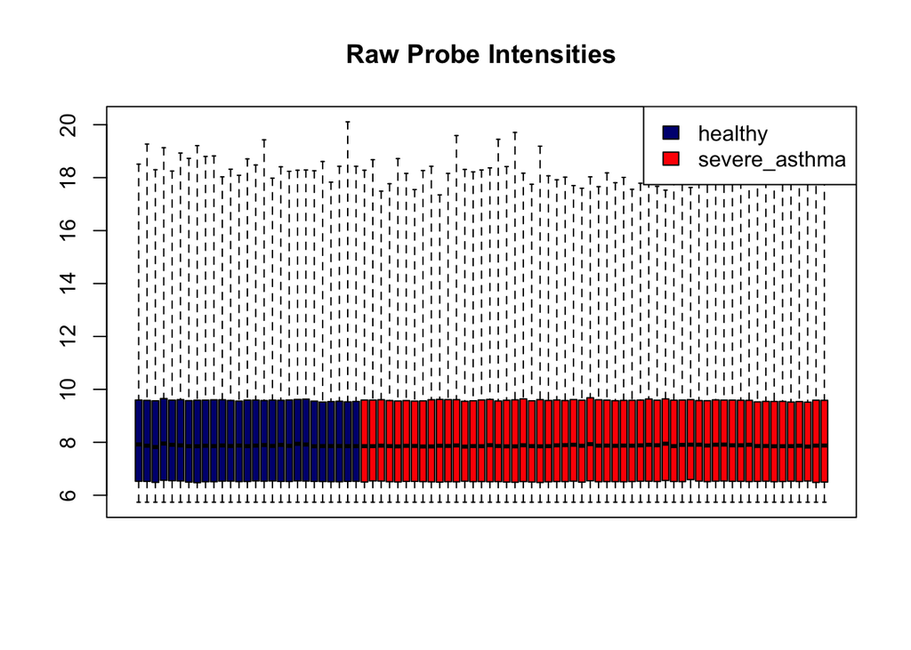

```
## The raw data is already normalized
```

### Pairwise Comparison between Status

Fit a linear model to RMA log-intensity values, fit this model to a contrast matrix for the comparison of interest, and apply empirical Bayes smoothing to obtain more precise standard errors.

A design model matrix for linear model

| Sample | healthy | severe_asthma |
| --- | --- | --- |
| GSM1541999_rep1 | 1 | 0 |
| GSM1542000_rep2 | 1 | 0 |
| GSM1542001_rep3 | 1 | 0 |
| GSM1542002_rep4 | 1 | 0 |
| GSM1542003_rep5 | 1 | 0 |
| GSM1542004_rep6 | 1 | 0 |
| GSM1542005_rep7 | 1 | 0 |
| GSM1542006_rep8 | 1 | 0 |
| GSM1542007_rep9 | 1 | 0 |
| GSM1542008_rep10 | 1 | 0 |
| GSM1542009_rep11 | 1 | 0 |
| GSM1542010_rep12 | 1 | 0 |
| GSM1542011_rep13 | 1 | 0 |
| GSM1542012_rep14 | 1 | 0 |
| GSM1542013_rep15 | 1 | 0 |
| GSM1542014_rep16 | 1 | 0 |
| GSM1542015_rep17 | 1 | 0 |
| GSM1542016_rep18 | 1 | 0 |
| GSM1542017_rep19 | 1 | 0 |
| GSM1542018_rep20 | 1 | 0 |
| GSM1542019_rep21 | 1 | 0 |
| GSM1542020_rep22 | 1 | 0 |
| GSM1542021_rep23 | 1 | 0 |
| GSM1542022_rep24 | 1 | 0 |
| GSM1542023_rep25 | 1 | 0 |
| GSM1542024_rep26 | 1 | 0 |
| GSM1542025_rep27 | 1 | 0 |
| GSM1542098_rep1 | 0 | 1 |
| GSM1542099_rep2 | 0 | 1 |
| GSM1542100_rep3 | 0 | 1 |

[output cut: 53 more lines]

A contract matrix for comparison

|  | severe_asthma-healthy |
| --- | --- |
| **healthy** | -1 |
| **severe_asthma** | 1 |

### Adjusting for Batch Effect

Check whether to adjust for batch effect.

Create a full model that includes all variables and a null model that only includes the batch variable. Note that as SVA computes the matrix x in t(batch model)%*%x=batch model, batch effect can be adjusted only when the solve function works.

Full model matrix

| Intercept | severe_asthma | 2012 |
| --- | --- | --- |
| 1 | 0 | 0 |
| 1 | 0 | 1 |
| 1 | 0 | 0 |
| 1 | 0 | 0 |
| 1 | 0 | 0 |
| 1 | 0 | 0 |
| 1 | 0 | 0 |
| 1 | 0 | 0 |
| 1 | 0 | 0 |
| 1 | 0 | 0 |
| 1 | 0 | 0 |
| 1 | 0 | 0 |
| 1 | 0 | 0 |
| 1 | 0 | 0 |
| 1 | 0 | 0 |
| 1 | 0 | 0 |
| 1 | 0 | 0 |
| 1 | 0 | 0 |
| 1 | 0 | 0 |
| 1 | 0 | 0 |
| 1 | 0 | 0 |
| 1 | 0 | 1 |
| 1 | 0 | 1 |
| 1 | 0 | 1 |
| 1 | 0 | 1 |
| 1 | 0 | 1 |
| 1 | 0 | 1 |
| 1 | 1 | 0 |
| 1 | 1 | 0 |
| 1 | 1 | 0 |

[output cut: 53 more lines]

Null model matrix

| Intercept | 2012 |
| --- | --- |
| 1 | 0 |
| 1 | 1 |
| 1 | 0 |
| 1 | 0 |
| 1 | 0 |
| 1 | 0 |
| 1 | 0 |
| 1 | 0 |
| 1 | 0 |
| 1 | 0 |
| 1 | 0 |
| 1 | 0 |
| 1 | 0 |
| 1 | 0 |
| 1 | 0 |
| 1 | 0 |
| 1 | 0 |
| 1 | 0 |
| 1 | 0 |
| 1 | 0 |
| 1 | 0 |
| 1 | 1 |
| 1 | 1 |
| 1 | 1 |
| 1 | 1 |
| 1 | 1 |
| 1 | 1 |
| 1 | 0 |
| 1 | 0 |
| 1 | 0 |

[output cut: 53 more lines]

Compute F statistic p-values adjusted for batch effect. Q-values are obtained by the Benjamini-Hochberg method. If the batch and the status are correlated, assign NA to the batch adjusted p- and q-values. If there is no batch variable or only one batch, assign p- and q-values computed by limma to the batch adjusted p-values

severe_asthma vs. healthy summary

| ID | logFC | AveExpr | t | P.Value | adj.P.Val | B | pValuesBatch | qValuesBatch |
| --- | --- | --- | --- | --- | --- | --- | --- | --- |
| A_23_P100001: 1 | Min. :-2.2398856 | Min. : 5.756 | Min. :-8.63166 | Min. :0.00000 | Min. :0.0000 | Min. :-6.307 | Min. :0.00000 | Min. :0.0000 |
| A_23_P100011: 1 | 1st Qu.:-0.0566402 | 1st Qu.: 6.559 | 1st Qu.:-1.02092 | 1st Qu.:0.07286 | 1st Qu.:0.2914 | 1st Qu.:-6.195 | 1st Qu.:0.06488 | 1st Qu.:0.2595 |
| A_23_P100022: 1 | Median :-0.0011065 | Median : 7.920 | Median :-0.02248 | Median :0.30684 | Median :0.6137 | Median :-5.793 | Median :0.28415 | Median :0.5682 |
| A_23_P100056: 1 | Mean :-0.0001681 | Mean : 8.333 | Mean : 0.01331 | Mean :0.37067 | Mean :0.5617 | Mean :-5.006 | Mean :0.35642 | Mean :0.5338 |
| A_23_P100074: 1 | 3rd Qu.: 0.0558638 | 3rd Qu.: 9.586 | 3rd Qu.: 1.03376 | 3rd Qu.:0.63275 | 3rd Qu.:0.8437 | 3rd Qu.:-4.724 | 3rd Qu.:0.61151 | 3rd Qu.:0.8153 |
| A_23_P100092: 1 | Max. : 1.9217090 | Max. :18.676 | Max. : 7.91146 | Max. :0.99998 | Max. :1.0000 | Max. :19.504 | Max. :1.00000 | Max. :1.0000 |
| (Other) :30883 | NA | NA | NA | NA | NA | NA | NA | NA |

### Assign Official Gene Symbol

Annotate official gene symbol to probes. Install the [R annotation database package](https://bioconductor.org/packages/3.7/data/annotation/) corresponding to your gene expression data. For any newly installed annotation databases, it can be added to the list anno_list reserved for future use.

```
## The platform used is  GPL6480
```

## Gene Expression Results Visualization

### Volcano Plots

Volcano plot (probes with a q-value <0.05 are present in red)

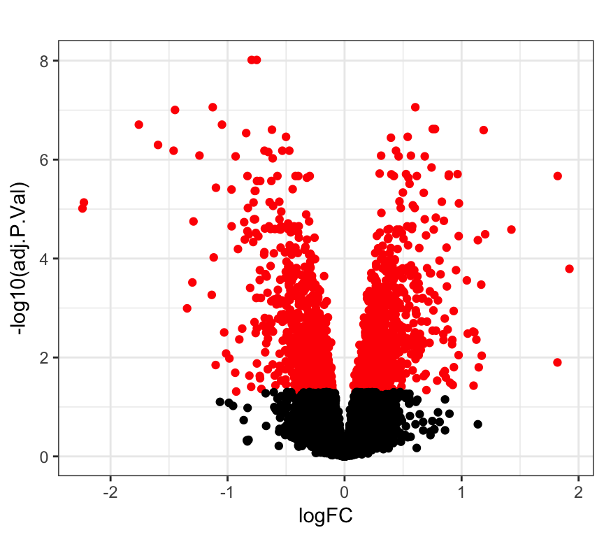

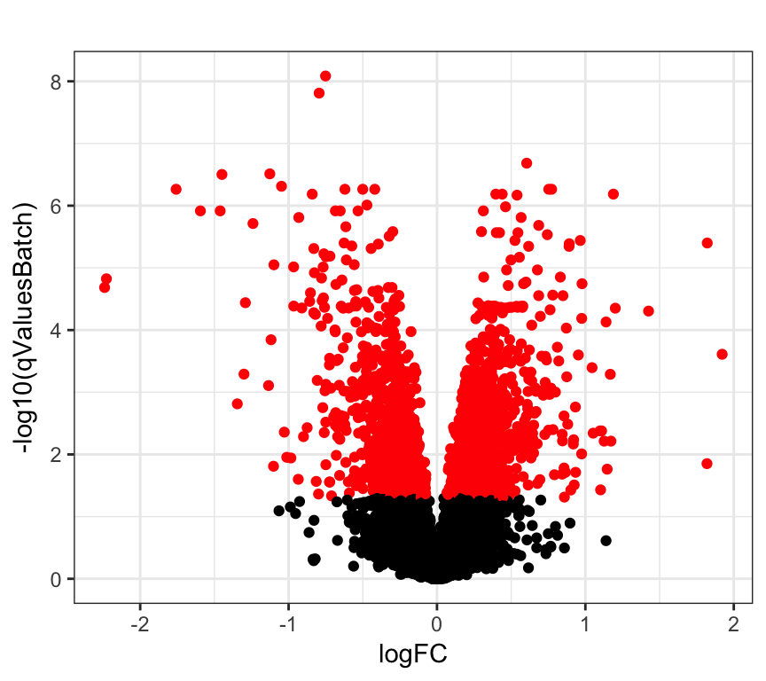

### Histograms

Histograms of p-value distributions

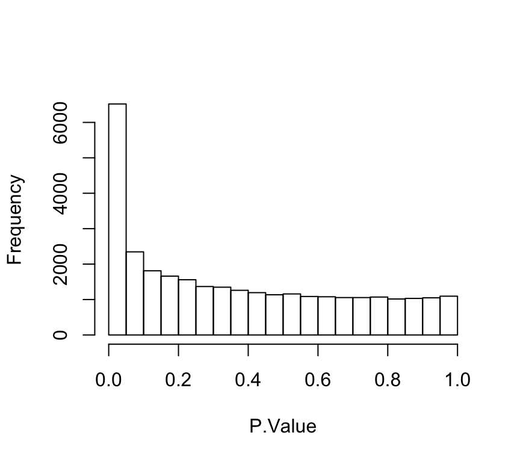

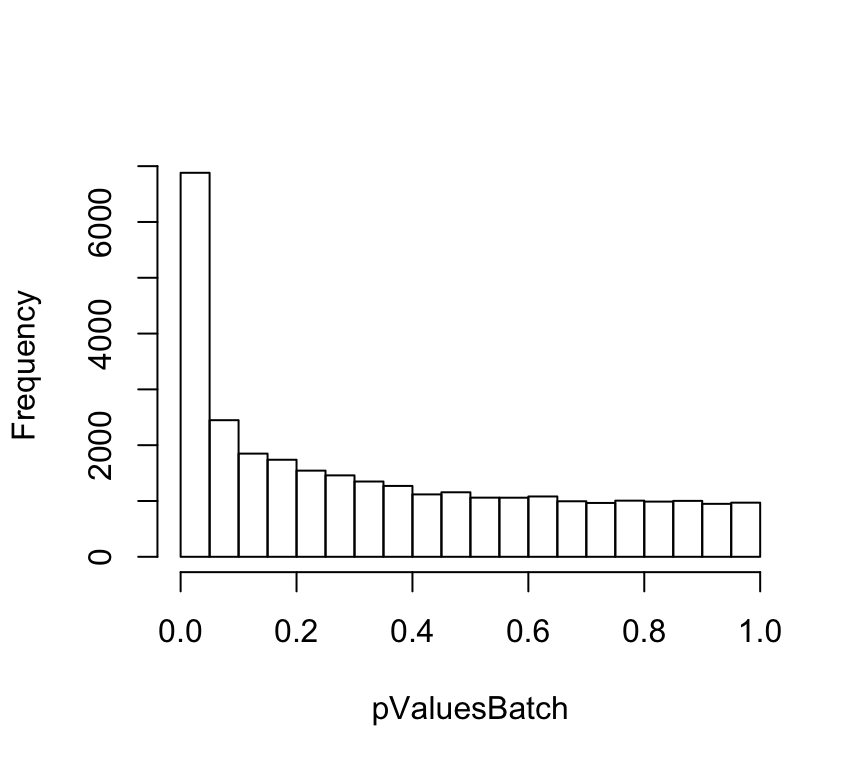

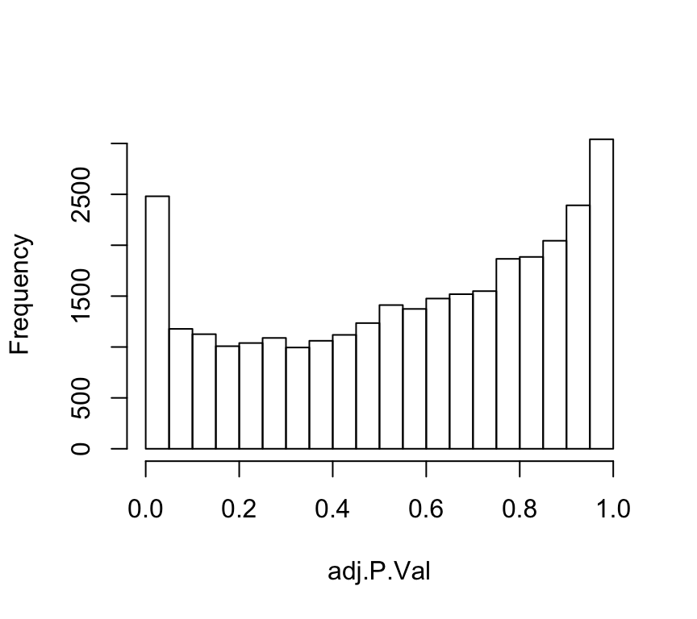

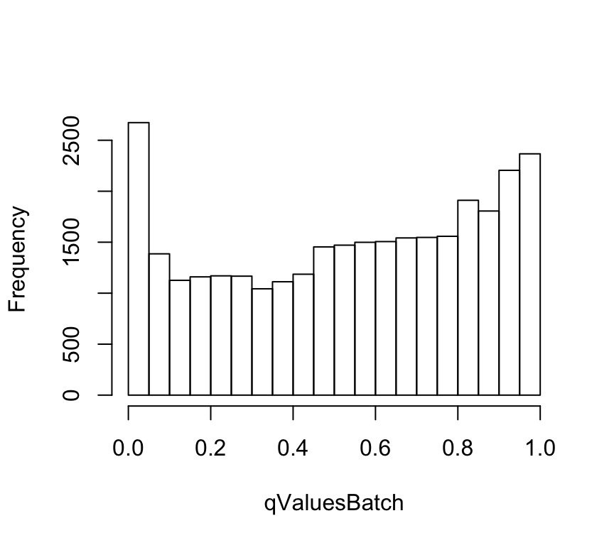

### Top 20 Differentially Expression Results

Show top 20 probes sorted by un-adjusted p-values

| ID | logFC | AveExpr | t | P.Value | adj.P.Val | B | pValuesBatch | qValuesBatch | SYMBOL |
| --- | --- | --- | --- | --- | --- | --- | --- | --- | --- |
| A_24_P327181 | -0.75 | 7.1 | -8.63 | 3.1e-13 | 9.7e-09 | 19.5 | 2.7e-13 | 8.2e-09 | WNK4 |
| A_23_P38334 | -0.79 | 6.57 | -8.48 | 6.3e-13 | 9.7e-09 | 18.86 | 1.0e-12 | 1.5e-08 | WNK4 |
| A_23_P127128 | 0.6 | 9.85 | 7.91 | 8.8e-12 | 8.7e-08 | 16.37 | 2.0e-11 | 2.1e-07 | DNAJC1 |
| A_23_P120504 | -1.13 | 8.32 | -7.86 | 1.1e-11 | 8.7e-08 | 16.14 | 4.0e-11 | 3.1e-07 | TMEM74B |
| A_23_P168541 | -1.45 | 11.62 | -7.78 | 1.6e-11 | 9.9e-08 | 15.81 | 5.1e-11 | 3.1e-07 | C7orf26 |
| A_24_P788878 | -1.05 | 8.73 | -7.59 | 3.9e-11 | 2.0e-07 | 14.98 | 9.5e-11 | 4.9e-07 | NA |
| A_24_P720185 | -1.76 | 10.77 | -7.56 | 4.5e-11 | 2.0e-07 | 14.84 | 1.6e-10 | 5.4e-07 | LINC01000 |
| A_23_P30315 | 0.75 | 10.12 | 7.49 | 6.2e-11 | 2.4e-07 | 14.53 | 1.8e-10 | 5.4e-07 | TRIM7 |
| A_24_P257224 | 0.77 | 6.99 | 7.46 | 7.0e-11 | 2.4e-07 | 14.42 | 2.1e-10 | 5.4e-07 | TPO |
| A_32_P29954 | -0.62 | 6.72 | -7.43 | 8.0e-11 | 2.5e-07 | 14.29 | 2.0e-10 | 5.4e-07 | ADARB2-AS1 |
| A_23_P111206 | 1.19 | 9.2 | 7.41 | 9.0e-11 | 2.5e-07 | 14.18 | 2.9e-10 | 6.5e-07 | FKBP5 |
| A_23_P101806 | -0.84 | 7.06 | -7.36 | 1.1e-10 | 2.9e-07 | 13.97 | 3.2e-10 | 6.5e-07 | HPN |
| A_23_P159937 | 0.54 | 8.48 | 7.29 | 1.5e-10 | 3.5e-07 | 13.69 | 3.7e-10 | 6.8e-07 | SLC6A8 |
| A_23_P89824 | -0.5 | 9.21 | -7.28 | 1.6e-10 | 3.5e-07 | 13.66 | 2.1e-10 | 5.4e-07 | TMEM241 |
| A_23_P428326 | 0.4 | 9.34 | 7.26 | 1.8e-10 | 3.6e-07 | 13.55 | 3.4e-10 | 6.5e-07 | TBC1D16 |
| A_24_P322426 | -1.59 | 10.43 | -7.17 | 2.6e-10 | 5.1e-07 | 13.18 | 8.3e-10 | 1.2e-06 | PTGIR |
| A_32_P216241 | -1.46 | 11.02 | -7.09 | 3.8e-10 | 6.6e-07 | 12.82 | 9.0e-10 | 1.2e-06 | PLAC4 |
| A_24_P314515 | -0.47 | 6.68 | -7.09 | 3.8e-10 | 6.6e-07 | 12.81 | 5.7e-10 | 9.8e-07 | HNF1A-AS1 |
| A_23_P411162 | -0.53 | 9.21 | -7.07 | 4.2e-10 | 6.6e-07 | 12.72 | 9.8e-10 | 1.2e-06 | PER2 |
| A_23_P131935 | 0.44 | 8.99 | 7.06 | 4.3e-10 | 6.6e-07 | 12.71 | 3.0e-10 | 6.5e-07 | FERMT1 |

### Boxplots for Top 6 Differentially Expressed Genes

This step helps to visualize and check the effect direction in the comparison.

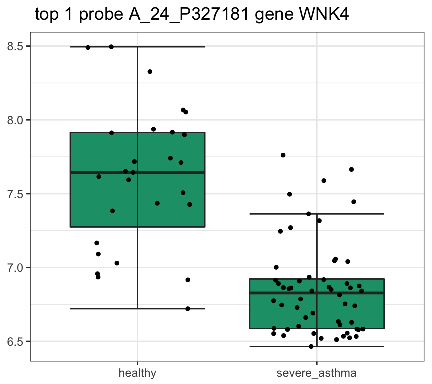

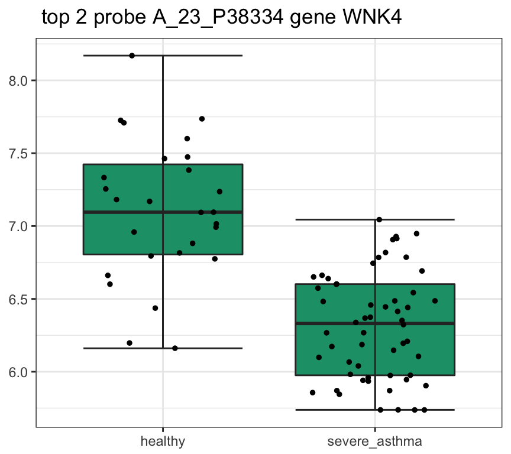

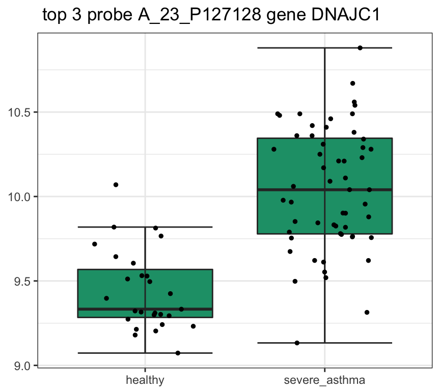

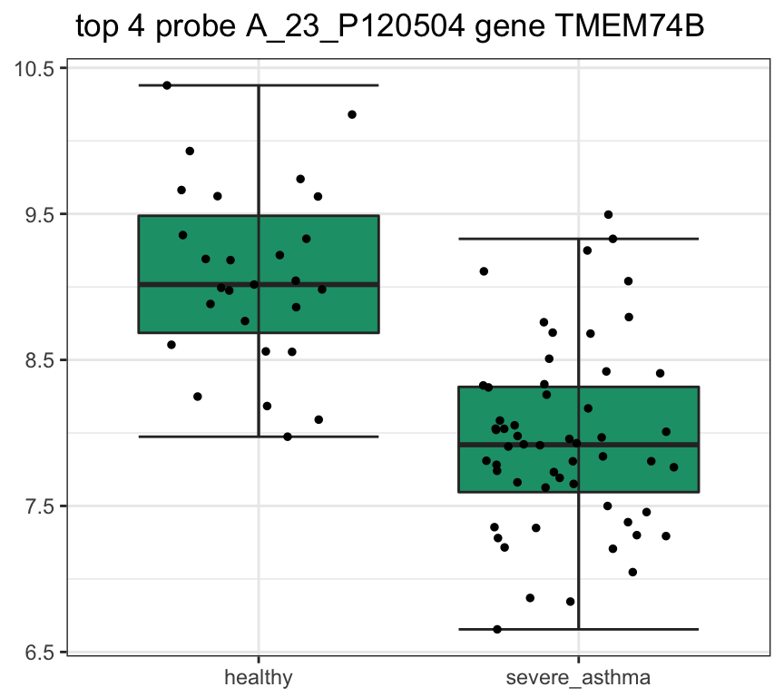

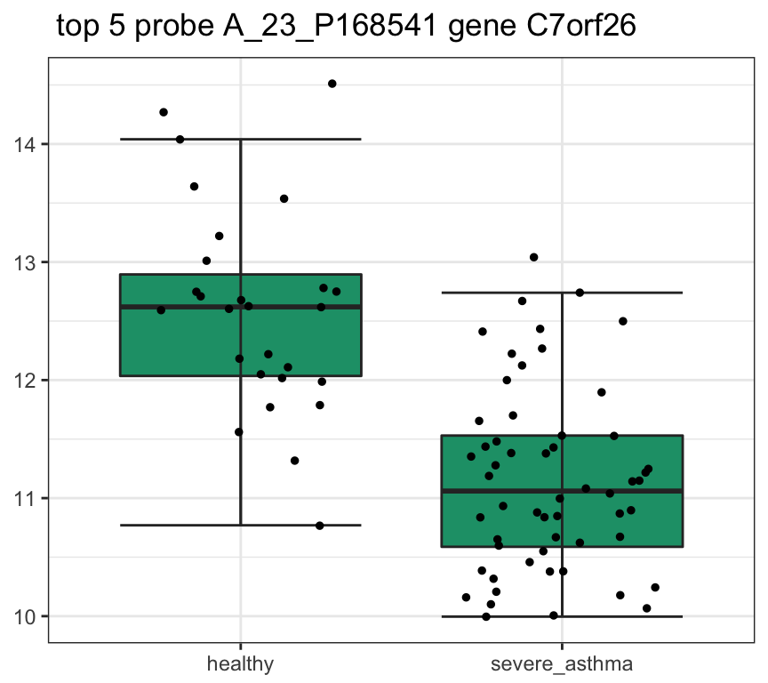

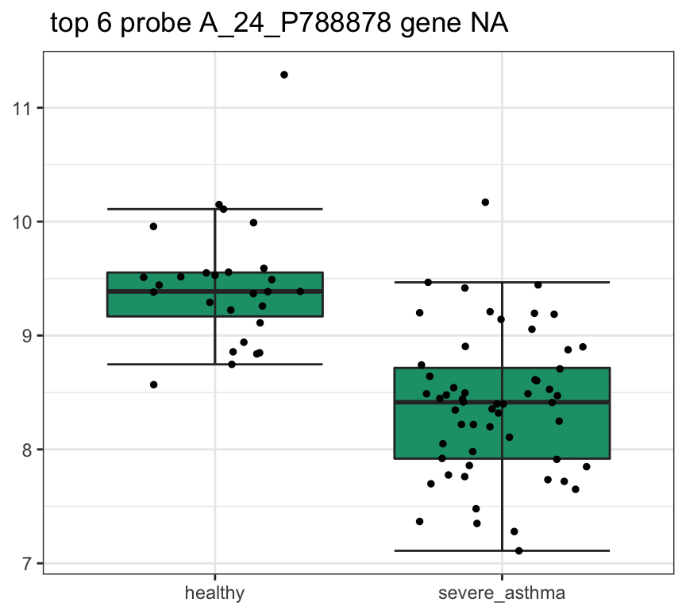

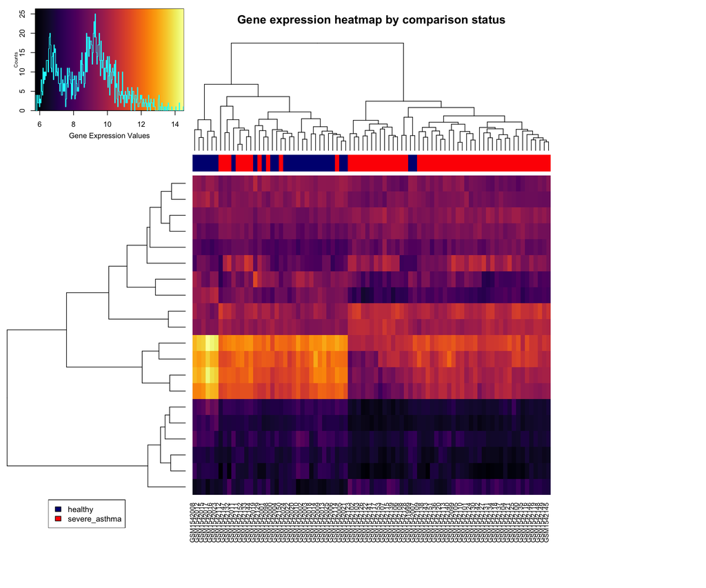

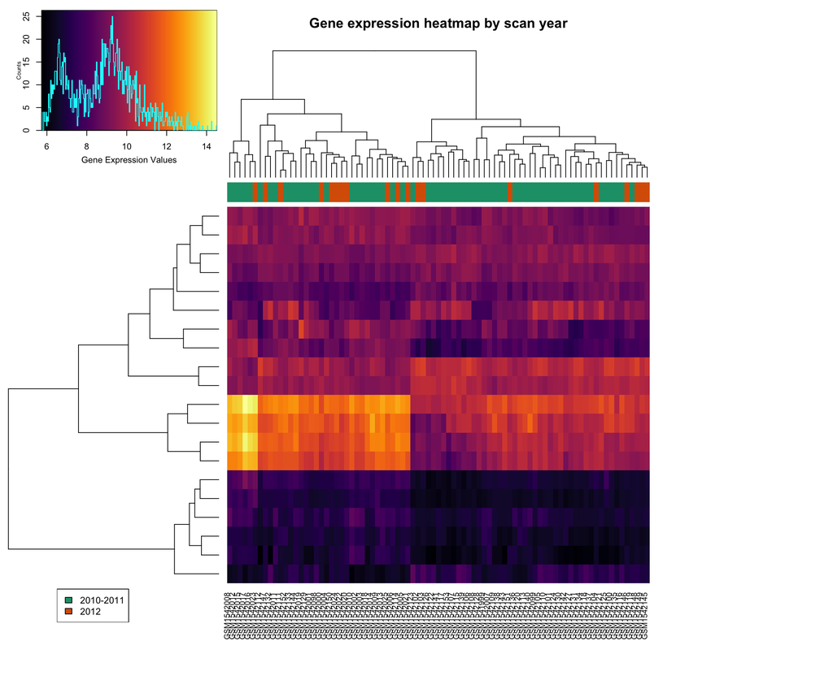

### Heatmap for Sample Correlation

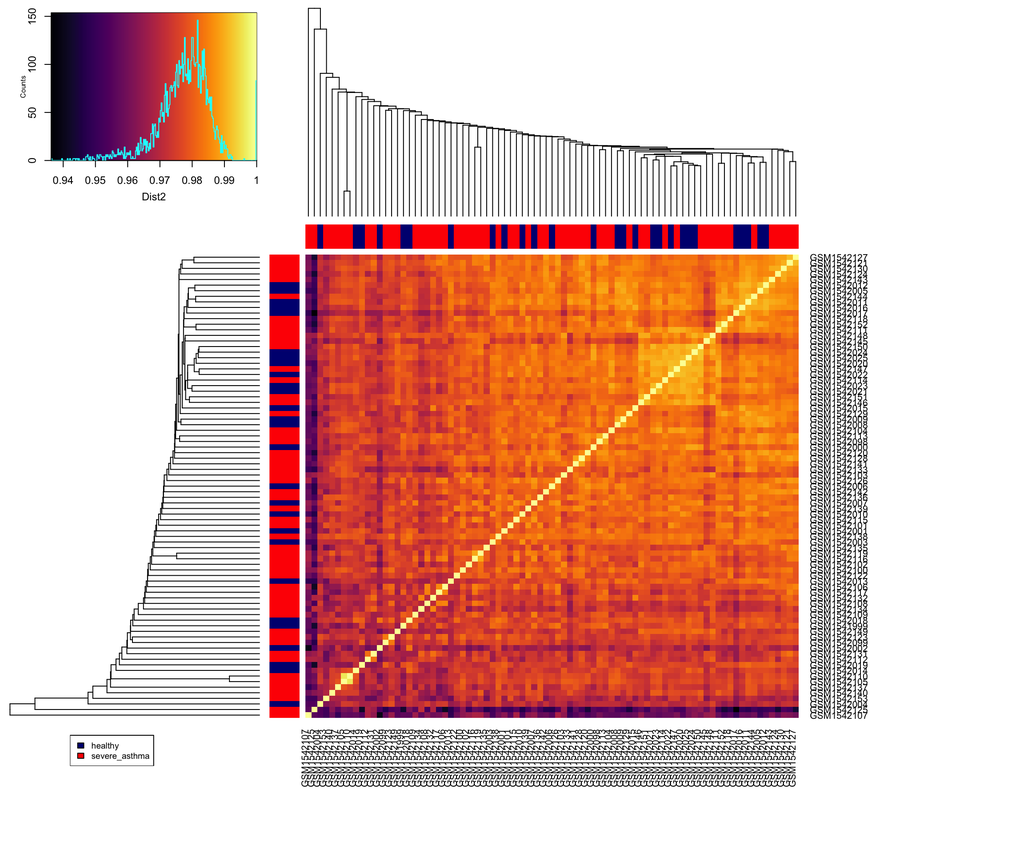

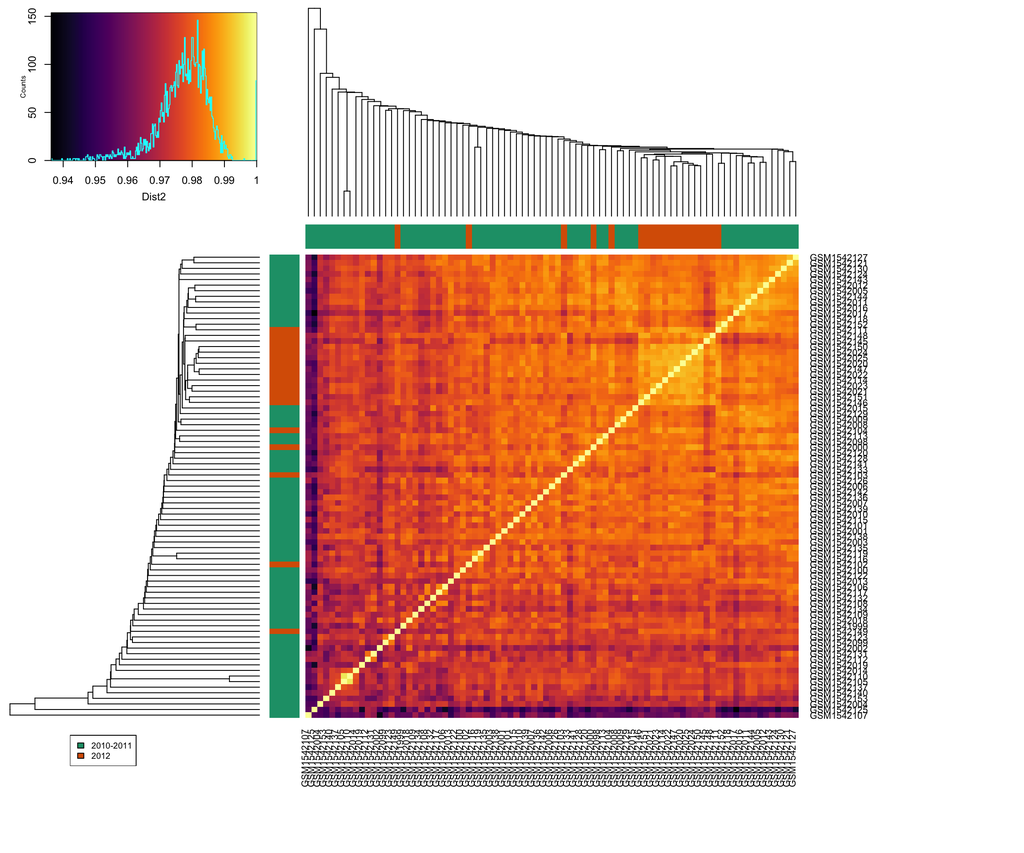

### Principal Component Analysis (PCA)

1. Compute PCs and variance explained by the first 10 PCs

Variance explained

| PC | Proportion of Variance (%) | Cumulative Proportion of Variance (%) |
| --- | --- | --- |
| PC1 | 11.27 | 11.27 |
| PC2 | 8.908 | 20.18 |
| PC3 | 7.223 | 27.4 |
| PC4 | 5.371 | 32.77 |
| PC5 | 5.219 | 37.99 |
| PC6 | 3.79 | 41.78 |
| PC7 | 3.278 | 45.06 |
| PC8 | 3.116 | 48.18 |
| PC9 | 2.878 | 51.05 |
| PC10 | 2.666 | 53.72 |

2. PCA plots

PCA plots are generated using the first two principle components colored by known factors (e.g. comparison status, donors and scan year), visualizing similarities between arrays and these similarities’ correlation to batch effects.

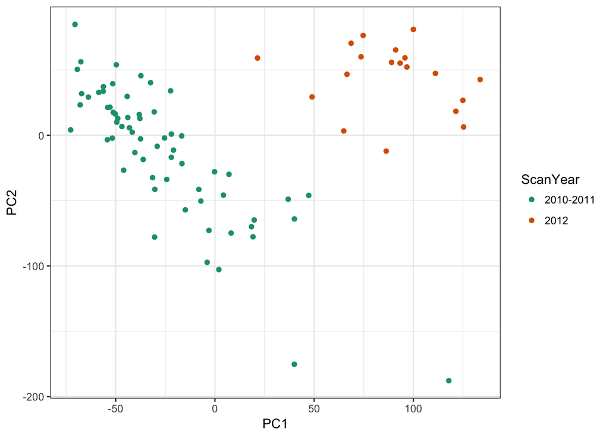

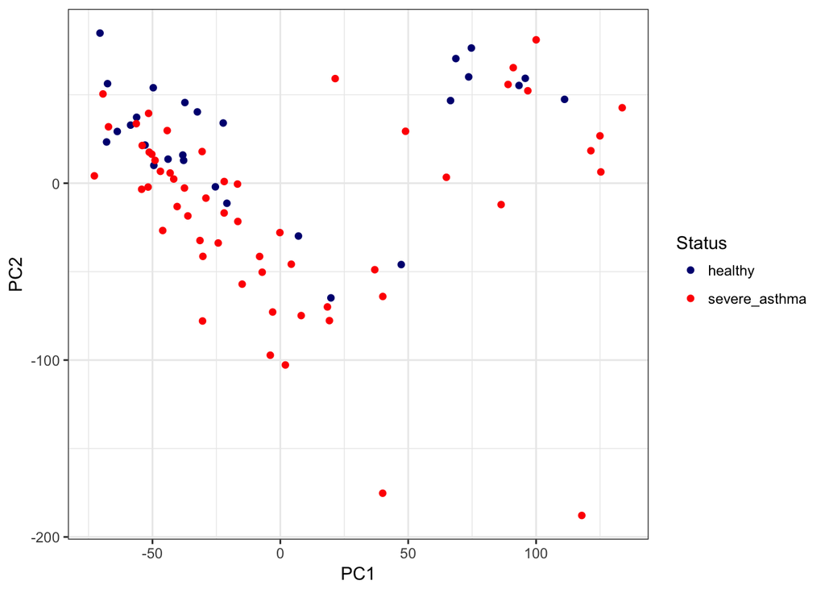

#### Session information

**R version 3.4.0 (2017-04-21)**

**Platform:** x86_64-apple-darwin15.6.0 (64-bit)

**locale:** en_US.UTF-8||en_US.UTF-8||en_US.UTF-8||C||en_US.UTF-8||en_US.UTF-8

**attached base packages:** *stats4*, *parallel*, *stats*, *graphics*, *grDevices*, *utils*, *datasets*, *methods* and *base*

**other attached packages:** *hgug4112a.db(v.3.2.3)*, *pander(v.0.6.1)*, *devtools(v.1.13.5)*, *gplots(v.3.0.1)*, *ggplot2(v.2.2.1)*, *viridis(v.0.4.0)*, *viridisLite(v.0.2.0)*, *hugene10sttranscriptcluster.db(v.8.7.0)*, *hgu133plus2.db(v.3.2.3)*, *org.Hs.eg.db(v.3.5.0)*, *annotate(v.1.54.0)*, *XML(v.3.98-1.8)*, *AnnotationDbi(v.1.40.0)*, *sva(v.3.24.4)*, *BiocParallel(v.1.10.1)*, *genefilter(v.1.58.1)*, *mgcv(v.1.8-17)*, *nlme(v.3.1-131)*, *limma(v.3.32.10)*, *oligo(v.1.42.0)*, *Biostrings(v.2.44.1)*, *XVector(v.0.16.0)*, *IRanges(v.2.10.2)*, *S4Vectors(v.0.14.3)*, *oligoClasses(v.1.38.0)*, *GEOquery(v.2.42.0)*, *Biobase(v.2.36.2)* and *BiocGenerics(v.0.24.0)*

**loaded via a namespace (and not attached):** *httr(v.1.2.1)*, *splines(v.3.4.0)*, *foreach(v.1.4.3)*, *gtools(v.3.5.0)*, *GenomeInfoDbData(v.0.99.0)*, *yaml(v.2.1.14)*, *RSQLite(v.1.1-2)*, *backports(v.1.1.0)*, *lattice(v.0.20-35)*, *digest(v.0.6.12)*, *GenomicRanges(v.1.28.3)*, *colorspace(v.1.3-2)*, *htmltools(v.0.3.6)*, *preprocessCore(v.1.38.1)*, *Matrix(v.1.2-10)*, *plyr(v.1.8.4)*, *affxparser(v.1.48.0)*, *zlibbioc(v.1.22.0)*, *xtable(v.1.8-2)*, *scales(v.0.4.1)*, *gdata(v.2.18.0)*, *affyio(v.1.46.0)*, *ff(v.2.2-13)*, *tibble(v.1.3.3)*, *withr(v.2.1.2)*, *SummarizedExperiment(v.1.6.3)*, *lazyeval(v.0.2.0)*, *survival(v.2.41-3)*, *magrittr(v.1.5)*, *memoise(v.1.1.0)*, *evaluate(v.0.10)*, *BiocInstaller(v.1.26.0)*, *tools(v.3.4.0)*, *matrixStats(v.0.52.2)*, *stringr(v.1.2.0)*, *munsell(v.0.4.3)*, *DelayedArray(v.0.2.7)*, *compiler(v.3.4.0)*, *GenomeInfoDb(v.1.12.2)*, *caTools(v.1.17.1)*, *rlang(v.0.2.0)*, *grid(v.3.4.0)*, *RCurl(v.1.95-4.8)*, *iterators(v.1.0.8)*, *labeling(v.0.3)*, *bitops(v.1.0-6)*, *rmarkdown(v.1.6)*, *gtable(v.0.2.0)*, *codetools(v.0.2-15)*, *DBI(v.0.6-1)*, *R6(v.2.2.1)*, *gridExtra(v.2.2.1)*, *knitr(v.1.16)*, *bit(v.1.1-12)*, *rprojroot(v.1.2)*, *KernSmooth(v.2.23-15)*, *stringi(v.1.1.5)* and *Rcpp(v.0.12.16)*